# Tarea Viscocidad

Raúl Frugone Zaror

2024-09-04

# Pregunta A)

Analice los datos anteriores identificando la característica de calidad a estudiar y supuestos distribucionales.

Primero leemos el vector de datos sobre la viscosidad de un producto químico, el cual corresponde al conjunto de datos sobre la variable que nos interesa estudiar, luego comprobamos el supuesto de normalidad en los datos para continuar cargando la función que permitirá gráficar lo solicitado en las preguntas

```r
viscosidad <- c(33.75, 33.05, 34.00, 33.81, 33.46, 34.92, 33.68, 33.27, 33.49, 32.20, 33.62, 33.00, 33.54,33.12,33.84)

#Al ser una cantidad reducida de datos, usare la prueba de Shapiro-Wilk

shapiro.test(viscosidad)
```

```
##
##  Shapiro-Wilk normality test
##
## data:  viscosidad
## W = 0.93661, p-value = 0.3416
```

Se obtuvo un valor-p mayor que 0.05, por lo que, no existe evidencia muestral suficiente para rechazar la hipótesis nula, a favor de que los datos se distribuyen normalmente. Esto nos permite continuar el análisis

# Pregunta B)

Grafique e interprete la carta de rangos móviles, observaciones individuales y medias móviles.}

```r
#Cargamos la función elaborada para generar los gráficos


valores <- data.frame(
  n = 2:25,
  A2 = c(1.880, 1.023, 0.729, 0.577, 0.483, 0.419, 0.373, 0.337, 0.308, 0.285,
         0.266, 0.249, 0.235, 0.223, 0.212, 0.203, 0.194, 0.187, 0.180, 0.173,
         0.167, 0.162, 0.157, 0.153),
  d2 = c(1.128, 1.693, 2.059, 2.326, 2.534, 2.704, 2.847, 2.970, 3.078, 3.173,
         3.258, 3.336, 3.407, 3.472, 3.532, 3.588, 3.640, 3.689, 3.735, 3.778,
         3.819, 3.858, 3.895, 3.931),
  D3 = c(0, 0, 0, 0, 0, 0.076, 0.136, 0.184, 0.223, 0.256,
         0.284, 0.308, 0.329, 0.348, 0.364, 0.379, 0.392, 0.404, 0.414, 0.425,
         0.434, 0.443, 0.452, 0.459),
  D4 = c(3.267, 2.575, 2.282, 2.115, 2.004, 1.924, 1.864, 1.816, 1.777, 1.744,
         1.716, 1.692, 1.671, 1.652, 1.636, 1.621, 1.608, 1.596, 1.586, 1.575,
         1.566, 1.557, 1.548, 1.541)
)

Carta <- function(datos_input, carta, n){
  valores_grupo <- valores[valores$n == n, ]
  A2 <- valores_grupo[,2]
  d2 <- valores_grupo[,3]
  D3 <- valores_grupo[,4]
  D4 <- valores_grupo[,5]

  x_barra<- mean(datos_input)
  dif=numeric(length(datos_input)-1)
  for(i in (length(datos_input)-1)){
  dif[i]<- max(datos_input[i], datos_input[i+1])
  }
  r_barra<- mean(dif)

  Datos_Moviles <- function(datos, n) {
    x_barra_movil <- numeric(length(datos) - n + 1)
    r_movil <- numeric(length(datos) - n + 1)

    for (i in 1:(length(datos) - n + 1)) {
      subgrupo <- datos[i:(i + n - 1)]
      x_barra_movil[i] <- mean(subgrupo)
      r_movil[i] <- max(subgrupo) - min(subgrupo)
    }

    x_r <- data.frame(x_barra_movil, r_movil)
    return(x_r)
  }

  # Calcular datos móviles
  x_r <- Datos_Moviles(datos_input, n)
  x_movil <- x_r[, 1]
  r_movil <- x_r[, 2]

  X_barra_movil <- mean(x_movil)
  r_barra_movil <- sum(r_movil) / length(r_movil)

if (carta == "X") {

  LCL <- x_barra -  (A2* r_barra)
  UCL <- x_barra + (A2* r_barra)
  MEDIA <- x_barra

  plot(datos_input, type="b", col=5, pch=16, main="Carta X", xlab="Subgrupo", ylab="", ylim = c(LCL -1, UCL+1))

  # Agregar tres líneas
  abline(h=LCL, col="red", lwd=2, lty=2)
  abline(h=UCL, col="red", lwd=2, lty=3)
  abline(h=MEDIA, col="darkgreen", lwd=2)
    }
if (carta == "R") {
  LCL <- D3 * r_barra
  UCL <- D4 * r_barra
  MEDIA <- r_barra

  plot(dif, type="b", col=5, pch=16, main="Carta R", xlab="Subgrupo", ylab="Rango", ylim = c(LCL -1, UCL+1))

  # Agregar tres líneas
  abline(h=LCL, col="red", lwd=2, lty=2)
  abline(h=UCL, col="red", lwd=2, lty=3)
  abline(h=MEDIA, col="darkgreen", lwd=2)
    }


  if(carta == "X_movil"){
    LCL <- X_barra_movil - A2*r_barra_movil
    UCL <- X_barra_movil + A2*r_barra_movil
    MEDIA <- X_barra_movil

    plot(x_movil, type="b", col=5, pch=16, main="Carta X-móvil", xlab="Subgrupo", ylab="Valor", ylim = c(LCL -1, UCL+1))

    # Agregar tres líneas
    abline(h=LCL, col="red", lwd=2, lty=2)
    abline(h=UCL, col="red", lwd=2, lty=3)
    abline(h=MEDIA, col="darkgreen", lwd=2)
  }
  if(carta == "R_movil"){
    LCL <- D3 * r_barra_movil
    UCL <- D4 * r_barra_movil
    MEDIA <- r_barra_movil

    plot(r_movil, type="b", col=5, pch=16, main="Carta R-móvil", xlab="Subgrupo", ylab="Rango Móvil", ylim = c(LCL -1, UCL+1))

    # Agregar tres líneas
    abline(h=LCL, col="red", lwd=2, lty=2)
    abline(h=UCL, col="red", lwd=2, lty=3)
    abline(h=MEDIA, col="darkgreen", lwd=2)
  }
}
```

Aplicamos la función para obtener los gráficos solicitados:

Para la carta X barra:

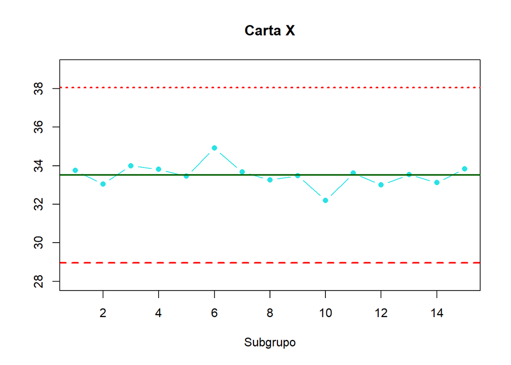

```r
#El 2 en este caso no genera ninguna diferencia, sin embargo, es necesario colocarlo para utilizar la función
Carta(viscosidad,"X", 2)
```

Interpretación:

En los datos acerca de la viscosidad no se visualiza ningun dato por fuera de los límites, reportando que los 15 lotes presentan medidas de viscosidad en miliPascal-segundo dentro de los estándares de calidad necesarios, además no se visualiza ninguna tendencia ni punto cercano a los límites que puedan alertar un posible descalibramiento en el proceso de producción.

Para la Carta de medias móviles:

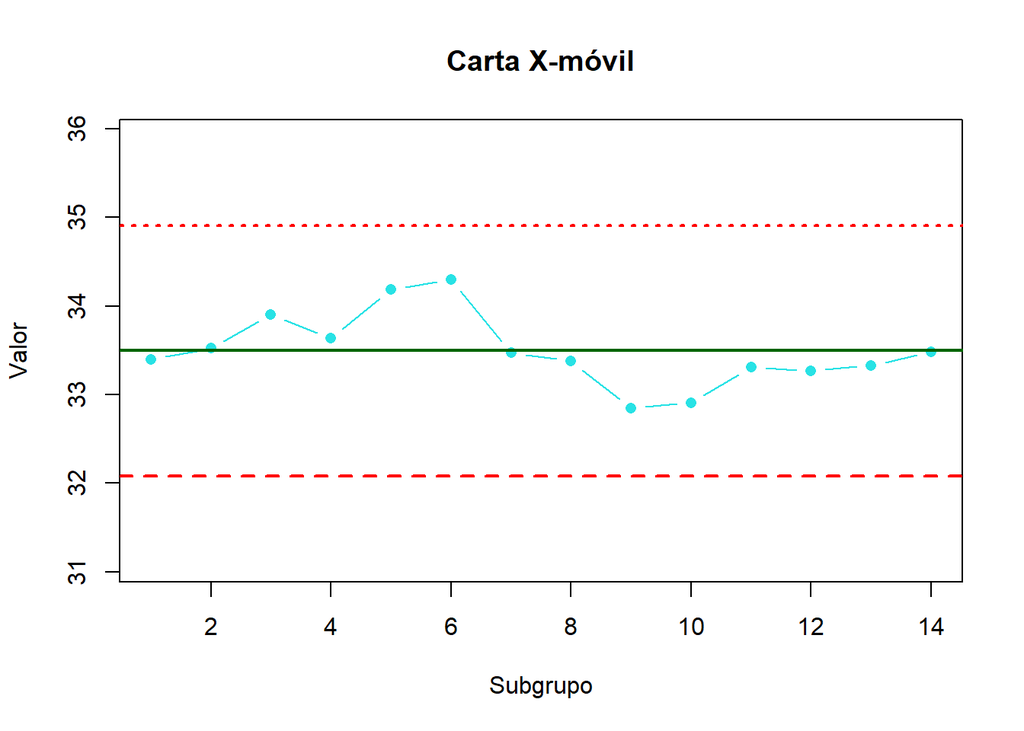

```r
Carta(viscosidad,"X_movil", 2)
```

Interpretación:

En los datos acerca de la viscosidad no se visualiza ningun dato por fuera de los límites, reportando que en los 14 subgrupos (cada uno de 2 lotes consecutivos) presentan medidas de viscosidad en miliPascal-segundo dentro de los estándares de calidad necesarios, además no se visualiza ninguna tendencia ni punto cercano a los límites que sugieran que existe un fallo en el proceso de producción.

Para la Carta de rangos móviles:

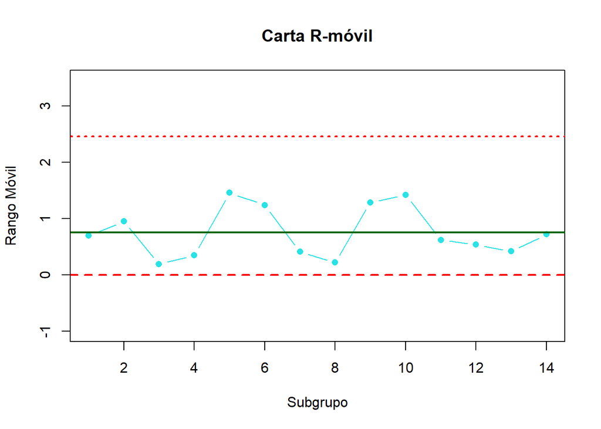

```r
Carta(viscosidad,"R_movil", 2)
```

Interpretación:

En los datos acerca de la viscosidad no se visualiza ningun dato por fuera de los límites, reportando que los 14 subgrupos presentan variación de viscosidad en miliPascal-segundo dentro de los estándares de calidad necesarios, también se ven más puntos por debajo de la media, lo que resulta beneficioso porque sugiere una menor variabilidad en el proceso, además no se visualiza ninguna tendencia ni punto cercano a los límites que puedan alertar problemas durante el proceso de producción.